# Sentiment Analysis & Topic Modeling

Flavius Mihai Bendres

2024-12-14

# **Introduction**

This report analyzes customer sentiment and identifies key topics from product reviews to understand customer opinions and feedback. The analysis uses Natural Language Processing (NLP) techniques, including sentiment analysis and topic modeling using LDA, to gain insights into customer satisfaction and product improvement areas. The data sources include sales data, customer profiles, feedback data, and classified product reviews.

## **Load Required Libraries**

```r
library(pacman)
pacman::p_load(
  here, readxl, tidyverse, jsonlite, caret, ggplot2, dplyr, scales, tidytext,
  syuzhet, corrplot, ggpubr, quanteda, topicmodels, topicdoc, quanteda.textstats,
  tidymodels, lm.beta, pROC, stringr
)
```

## **Load Data**

```r
sales_data_path <- here("D:/Data - Python/Big data Analytics", "sales_users_and_feedback_data.xlsx")
profiles_path <- here("D:/Data - Python/Big data Analytics", "sales_users_and_feedback_data.xlsx")
feedback_path <- here("D:/Data - Python/Big data Analytics", "sales_users_and_feedback_data.xlsx")
reviews_path <- here("D:/Data - Python/Big data Analytics", "classified_reviews1000.json")

sales_data <- read_xlsx(sales_data_path, sheet = "Sales Data")
profiles <- read_xlsx(profiles_path, sheet = "Profiles")
feedback <- read_xlsx(feedback_path, sheet = "Feedback Data")
reviews <- fromJSON(reviews_path)
```

## **Data Exploration**

```r
head(sales_data)
```

```
## # A tibble: 6 × 7
##   UserID ProductID    product_type    Date                Revenue Month Discount
##    <dbl> <chr>        <chr>           <dttm>                <dbl> <dbl>    <dbl>
## 1   1000 B00LIX177I_0 Mobile Accesso… 2020-10-16 00:00:00    11.6    10    0.108
## 2   1000 B01HCVG51M_0 Home Entertain… 2020-02-03 00:00:00  2210       2    0
## 3   1000 B00YD3DBOC_0 Computers and … 2020-01-25 00:00:00  1102.      1    0.108
## 4   1000 B00IVPU7AO_8 Storage Devices 2020-03-19 00:00:00    65       3    0
## 5   1001 B00WEVFK3U_0 Mobile Accesso… 2021-11-02 00:00:00    11.6    11    0.108
## 6   1001 B006L6ZHAU_0 Computers and … 2022-04-27 00:00:00  1235       4    0
```

```r
head(feedback)
```

```
## # A tibble: 6 × 7
##   UserID ProductID    FeedbackDate        FeedbackType       FeedbackDetail
##    <dbl> <chr>        <dttm>              <chr>              <chr>
## 1   1000 B00LIX177I_0 2020-11-08 00:00:00 Product Suggestion Suggestions for ne…
## 2   1001 B00TIT3KYC_1 2022-02-06 00:00:00 Product Suggestion Suggestions for ne…
## 3   1002 B00170IBF8_0 2022-04-19 00:00:00 Delivery Issue     Concerns about del…
## 4   1003 B007IV7KRU_0 2021-07-03 00:00:00 Delivery Issue     Concerns about del…
## 5   1003 B01HCVG51M_0 2021-12-24 00:00:00 General Inquiry    General questions …
## 6   1005 B00GND21H8_0 2022-01-17 00:00:00 Technical Issue    Issues with device…
## # ℹ 2 more variables: FeedbackSeverity <chr>, SatisfactionScore <dbl>
```

```r
summary(sales_data)
```

```
##      UserID        ProductID         product_type
##  Min.   :  1000   Length:689471      Length:689471
##  1st Qu.: 28437   Class :character   Class :character
##  Median : 55930   Mode  :character   Mode  :character
##  Mean   : 55961
##  3rd Qu.: 83454
##  Max.   :110999
##
##       Date                           Revenue           Month
##  Min.   :2020-01-01 00:00:00.00   Min.   :  11.6   Min.   : 1.000
##  1st Qu.:2020-08-15 00:00:00.00   1st Qu.:  13.0   1st Qu.: 3.000
##  Median :2021-03-22 00:00:00.00   Median :  65.0   Median : 6.000
##  Mean   :2021-03-25 17:06:30.44   Mean   : 550.5   Mean   : 6.066
##  3rd Qu.:2021-11-09 00:00:00.00   3rd Qu.:1101.7   3rd Qu.: 9.000
##  Max.   :2022-06-18 00:00:00.00   Max.   :2210.0   Max.   :12.000
##                                   NA's   :4951
##     Discount
##  Min.   :0.00000
##  1st Qu.:0.00000
##  Median :0.00000
##  Mean   :0.04312
##  3rd Qu.:0.10796
##  Max.   :0.10796
##
```

```r
colSums(is.na(sales_data))
```

```
##       UserID    ProductID product_type         Date      Revenue        Month
##            0            0            0            0         4951            0
##     Discount
##            0
```

```r
colSums(is.na(reviews))
```

```
##            overall           verified         reviewTime         reviewerID
##                  0                  0                  0                  0
##               asin             Color:              Size:      Package Type:
##                  0                713                872                913
##             Style:          Capacity: Product Packaging:             Model:
##                875                957                969                993
##            Length:            Format:        Style Name:  Package Quantity:
##                992                990                997                997
##        Offer Type:        Color Name:     Configuration:             Shape:
##                994                998                997                997
##       reviewerName         reviewText            summary     unixReviewTime
##                  0                  0                  0                  0
##        productType               vote              image
##                  0                712                  0
```

```r
product_types_count <- sales_data %>%
  count(product_type, sort = TRUE)

print(product_types_count)
```

```
## # A tibble: 17 × 2
##    product_type                           n
##    <chr>                              <int>
##  1 Mobile Accessories                208828
##  2 Audio Equipment                   135187
##  3 Home Entertainment                120727
##  4 Computers and Accessories          65245
##  5 Storage Devices                    57040
##  6 Cameras and Photography            38958
##  7 Networking Devices                 22243
##  8 Other Electronics                  20000
##  9 Wearable Technology                 9634
## 10 Computer Accessories                5468
## 11 Car Audio Equipment                 2017
## 12 Graphics Cards                       738
## 13 Tablets and Accessories              733
## 14 GPS Devices                          708
## 15 GPS Navigation Devices               675
## 16 Tablets/Computers and Accessories    655
## 17 Tablets and Computers                615
```

## **Data Cleaning & Processing**

I can see that there are different labels for similar product types which can lead to skeId insights I’ll identify similar categories and create a mapping of them to be applied to our data (mapping created below in the functions and utilities section)

```r
# I apply the mapping to the product_type column
sales_data <- sales_data %>%
  dplyr::mutate(product_type = case_when(
    product_type %in% c("Mobile Accessories") ~ "Mobile Accessories",
    product_type %in% c("Computers and Accessories", "Computer Accessories", "Tablets and Accessories", "Tablets/Computers and Accessories", "Tablets and Computers") ~ "Tablets/Computers and Accessories",
    product_type %in% c("Audio Equipment") ~ "Audio Equipment",
    product_type %in% c("Home Entertainment") ~ "Home Entertainment",
    product_type %in% c("Storage Devices") ~ "Storage Devices",
    product_type %in% c("Cameras and Photography") ~ "Cameras and Photography",
    product_type %in% c("Networking Devices") ~ "Networking Devices",
    product_type %in% c("Other Electronics") ~ "Other Electronics",
    product_type %in% c("Iarable Technology") ~ "Iarable Technology",
    product_type %in% c("Car Audio Equipment") ~ "Car Audio Equipment",
    product_type %in% c("Graphics Cards") ~ "Graphics Cards",
    product_type %in% c("GPS Devices", "GPS Navigation Devices") ~ "GPS Devices",
    TRUE ~ product_type # Keep the original product_type if it doesn't match any condition
  ))

# View the first few rows to verify
head(sales_data)
```

```
## # A tibble: 6 × 7
##   UserID ProductID    product_type    Date                Revenue Month Discount
##    <dbl> <chr>        <chr>           <dttm>                <dbl> <dbl>    <dbl>
## 1   1000 B00LIX177I_0 Mobile Accesso… 2020-10-16 00:00:00    11.6    10    0.108
## 2   1000 B01HCVG51M_0 Home Entertain… 2020-02-03 00:00:00  2210       2    0
## 3   1000 B00YD3DBOC_0 Tablets/Comput… 2020-01-25 00:00:00  1102.      1    0.108
## 4   1000 B00IVPU7AO_8 Storage Devices 2020-03-19 00:00:00    65       3    0
## 5   1001 B00WEVFK3U_0 Mobile Accesso… 2021-11-02 00:00:00    11.6    11    0.108
## 6   1001 B006L6ZHAU_0 Tablets/Comput… 2022-04-27 00:00:00  1235       4    0
```

```r
# counting the product types
product_types_count_updated <- sales_data %>%
  count(product_type, sort = TRUE)

# at a first glance, Mobile Accessories are the highest sold items at: 208828
# may be relevant to check how much revenue do Mobile Accessories bring compared to the ratings/demographics/region

# Now I do the same but for the reviews data_set. This is useful for future merging of the data sets
product_types_review <- reviews %>%
  select(productType)

# How many product types do I have in the review data set?
product_types_count_review <- reviews %>%
  count(productType, sort = TRUE)

print(product_types_count_review)
```

```
##                          productType   n
## 1                 Mobile Accessories 303
## 2                    Audio Equipment 196
## 3                 Home Entertainment 175
## 4          Computers and Accessories  94
## 5                    Storage Devices  83
## 6            Cameras and Photography  56
## 7                 Networking Devices  32
## 8                  Other Electronics  29
## 9                Wearable Technology  14
## 10              Computer Accessories   8
## 11               Car Audio Equipment   3
## 12                       GPS Devices   1
## 13            GPS Navigation Devices   1
## 14                    Graphics Cards   1
## 15           Tablets and Accessories   1
## 16             Tablets and Computers   1
## 17 Tablets/Computers and Accessories   1
```

```r
# I will apply the same mapping to ensure consistancy since they have the same categories
reviews <- reviews %>%
  dplyr::mutate(productType = case_when(
    productType %in% c("Mobile Accessories") ~ "Mobile Accessories",
    productType %in% c("Computers and Accessories", "Computer Accessories", "Tablets and Accessories", "Tablets/Computers and Accessories", "Tablets and Computers") ~ "Tablets/Computers and Accessories",
    productType %in% c("Audio Equipment") ~ "Audio Equipment",
    productType %in% c("Home Entertainment") ~ "Home Entertainment",
    productType %in% c("Storage Devices") ~ "Storage Devices",
    productType %in% c("Cameras and Photography") ~ "Cameras and Photography",
    productType %in% c("Networking Devices") ~ "Networking Devices",
    productType %in% c("Other Electronics") ~ "Other Electronics",
    productType %in% c("Iarable Technology") ~ "Iarable Technology",
    productType %in% c("Car Audio Equipment") ~ "Car Audio Equipment",
    productType %in% c("Graphics Cards") ~ "Graphics Cards",
    productType %in% c("GPS Devices", "GPS Navigation Devices") ~ "GPS Devices",
    TRUE ~ productType # Keep the original product_type if it doesn't match any condition
  ))

# updated product types and their counts
product_types_count_review_updated <- reviews %>%
  count(productType, sort = TRUE)

print(product_types_count_review_updated)
```

```
##                          productType   n
## 1                 Mobile Accessories 303
## 2                    Audio Equipment 196
## 3                 Home Entertainment 175
## 4  Tablets/Computers and Accessories 105
## 5                    Storage Devices  83
## 6            Cameras and Photography  56
## 7                 Networking Devices  32
## 8                  Other Electronics  29
## 9                Wearable Technology  14
## 10               Car Audio Equipment   3
## 11                       GPS Devices   2
## 12                    Graphics Cards   1
```

## **Descriptive Questions**

1. Sales Trends “What are the sales trends across different product categories?”- “How has revenue changed over time for various product types?”

I saw a pattern where two distinct product IDs B00RJQ6UZ2_0 and B00EJ9405O_0 had overlapping product types which made the summary show the same min revenue for all product types of 11.6, thus I first check for inconsistencies betIen datasets 1: Products with multiple categories

```r
inconsistent_products <- sales_data %>%
  group_by(ProductID) %>%
  summarize(
    categories = n_distinct(product_type),
    category_list = paste(unique(product_type), collapse = ", "),
    avg_price = mean(Revenue)
  ) %>%
  filter(categories > 1) %>%
  arrange(desc(avg_price))

print("Products with multiple categories:")
```

```
## [1] "Products with multiple categories:"
```

```r
print(inconsistent_products)
```

```
## # A tibble: 2 × 4
##   ProductID    categories category_list                                avg_price
##   <chr>             <int> <chr>                                            <dbl>
## 1 B00EJ9405O_0         12 Mobile Accessories, Home Entertainment, Aud…     373.
## 2 B00RJQ6UZ2_0         12 Home Entertainment, Audio Equipment, Mobile…      12.4
```

```r
# Mapping for both problematic products
category_mapping <- tibble(
  ProductID = c(
    "B00RJQ6UZ2_0",  # Based on reviews dataset
    "B00EJ9405O_0"   # Based on reviews dataset
  ),
  correct_category = c(
    "Mobile Accessories",
    "Audio Equipment"
  )
)
```

Overlapping product categories caused incorrect summaries, such as the same Min_Revenue value across all categories.

```r
sales_data <- sales_data %>%
  left_join(category_mapping, by = "ProductID") %>%
  dplyr::mutate(
    product_type = coalesce(correct_category, product_type) # The coalesce() function replaces product_type with the manually defined correct_category if it exists.
    # If no correction is defined, it retains the original category, making the solution both precise and minimally invasive.
  ) %>%
  select(-correct_category)

# Verification
print("After fixing categories for both products:")
```

```
## [1] "After fixing categories for both products:"
```

```r
sales_data %>%
  filter(ProductID %in% c("B00RJQ6UZ2_0", "B00EJ9405O_0")) %>%
  count(ProductID, product_type)
```

```
## # A tibble: 2 × 3
##   ProductID    product_type            n
##   <chr>        <chr>               <int>
## 1 B00EJ9405O_0 Audio Equipment     29756
## 2 B00RJQ6UZ2_0 Mobile Accessories 102429
```

```r
# Where do I have the NA values?
colSums(is.na(sales_data)) # 4951 under sales_data
```

```
##       UserID    ProductID product_type         Date      Revenue        Month
##            0            0            0            0         4951            0
##     Discount
##            0
```

```r
missing_revenue <- sales_data %>%
  filter(is.na(Revenue))

median_revenue_by_type <- sales_data %>%
  group_by(product_type) %>%
  summarize(median_revenue = median(Revenue, na.rm = TRUE))

print(median_revenue_by_type)
```

```
## # A tibble: 12 × 2
##    product_type                      median_revenue
##    <chr>                                      <dbl>
##  1 Audio Equipment                              390
##  2 Cameras and Photography                     1430
##  3 Car Audio Equipment                           NA
##  4 GPS Devices                                   NA
##  5 Graphics Cards                                NA
##  6 Home Entertainment                          2210
##  7 Mobile Accessories                            13
##  8 Networking Devices                            65
##  9 Other Electronics                             65
## 10 Storage Devices                               65
## 11 Tablets/Computers and Accessories           1235
## 12 Wearable Technology                          455
```

Possible manual entry mistakes or system errors during data collection. Sales that Ire initiated but not completed Returns/Refunds?

The only three columns that have NAs now are GPS devices, Graphics cards, and Car Audio Equipment It is correct that I cannot attach a median revenue to these as I do not have any revenue attached to them to begin with Since these categories lack any revenue records I’ll exclude these specific product types from imputation and instead treat them separately (if needed)

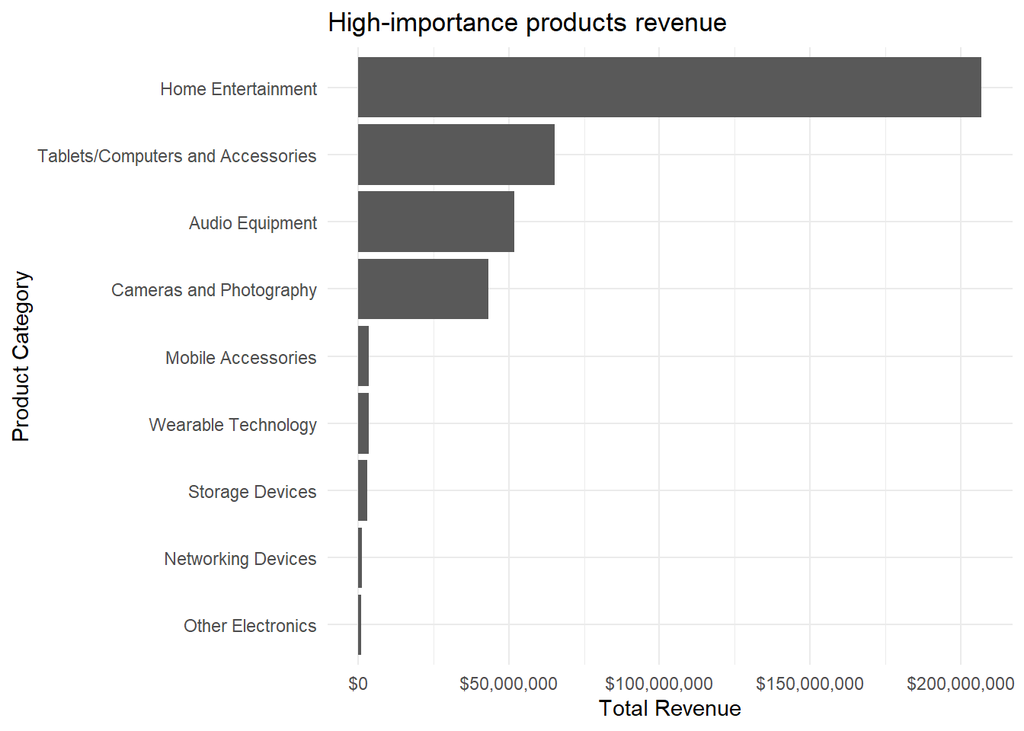

```r
median_tablets_computers <- median_revenue_by_type %>%
  filter(product_type == "Tablets/Computers and Accessories") %>%
  pull(median_revenue)

sales_data <- sales_data %>%
  dplyr::mutate(Revenue = ifelse(is.na(Revenue) & product_type == "Tablets/Computers and Accessories",
                                 median_tablets_computers, Revenue))

# Excluding rows with product types that have no revenue data for now
sales_data <- sales_data %>%
  filter(!product_type %in% c("Car Audio Equipment", "GPS Devices", "Graphics Cards"))

# HOIVER, Excluding rows could introduce bias if the missing revenue is not random.
# For example, low-revenue products may disproportionately lack data, skewing the analysis toward higher-revenue categories.

summary_temporary <- sales_data %>%
  group_by(product_type) %>%
  summarize(
    Total_Revenue = sum(Revenue),
    Median_Revenue = median(Revenue),
    Min_Revenue = min(Revenue),
    Max_Revenue = max(Revenue),
    n_transactions = n()
  ) %>%
  arrange(desc(Total_Revenue))

ggplot(summary_temporary, aes(x = reorder(product_type, Total_Revenue), y = Total_Revenue)) +
  geom_bar(stat = "identity") +
  coord_flip() +
  labs(title = "High-importance products revenue",
       x = "Product Category",
       y = "Total Revenue") +
  theme_minimal() +
  scale_y_continuous(labels = dollar)
```

### **Defining the high importance product types**

Based on the output, I will pick the “high-importance product types” Home Entertainment products dominate the revenue, contributing 55.9% of the total revenue. Tablets/Computers and Accessories contribute to 17.6% of the total revenue and Audio Equipment (14%) and Cameras and Photography (11.6%) are significant contributors And the final product I think it’s relevant to include, even though it accounts for only 0,911% of total revenue is Mobiel Accessories due to having the largest transactions volume at: 271151

```r
sales_data <- sales_data %>%
  filter(!product_type %in% c("Other Electronics", "Networking Devices", "Storage Devices",
                              "Iarable Technology"))

# Filtering enhances focus on high-impact categories but risks losing insights into underperforming segments that might be valuable for growth or customer retention strategies.

# summary by product type
summary_fixed <- sales_data %>%
  group_by(product_type) %>%
  summarize(
    Total_Revenue = sum(Revenue),
    Median_Revenue = median(Revenue),
    Min_Revenue = min(Revenue),
    Max_Revenue = max(Revenue),
    n_transactions = n()
  ) %>%
  arrange(desc(Total_Revenue))

# total revenue var
total_revenue_all <- sum(summary_fixed$Total_Revenue)

# creating a % of total revenue for each product type
summary_fixed <- summary_fixed %>%
  dplyr::mutate(Percentage_of_Total = (Total_Revenue / total_revenue_all) * 100)

print(summary_fixed)
```

```
## # A tibble: 6 × 7
##   product_type              Total_Revenue Median_Revenue Min_Revenue Max_Revenue
##   <chr>                             <dbl>          <dbl>       <dbl>       <dbl>
## 1 Home Entertainment           206957599.           2210      1971.         2210
## 2 Tablets/Computers and Ac…     65179707.           1235       174.         1235
## 3 Audio Equipment               51789061.            390       348.          390
## 4 Cameras and Photography       43106897.           1430      1276.         1430
## 5 Mobile Accessories             3372827.             13        11.6          13
## 6 Wearable Technology            3362276.            455       406.          455
## # ℹ 2 more variables: n_transactions <int>, Percentage_of_Total <dbl>
```

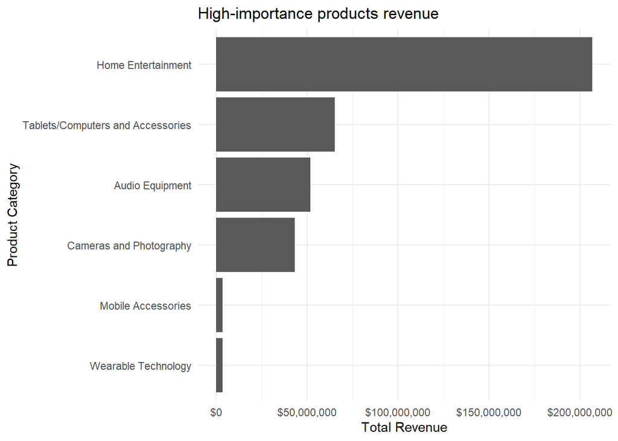

```r
ggplot(summary_fixed, aes(x = reorder(product_type, Total_Revenue), y = Total_Revenue)) +
  geom_bar(stat = "identity") +
  coord_flip() +
  labs(title = "High-importance products revenue",
       x = "Product Category",
       y = "Total Revenue") +
  theme_minimal() +
  scale_y_continuous(labels = dollar)
```

### **Reviews Dataset**

```r
colSums(is.na(reviews)) #many columns with missing values
```

```
##            overall           verified         reviewTime         reviewerID
##                  0                  0                  0                  0
##               asin             Color:              Size:      Package Type:
##                  0                713                872                913
##             Style:          Capacity: Product Packaging:             Model:
##                875                957                969                993
##            Length:            Format:        Style Name:  Package Quantity:
##                992                990                997                997
##        Offer Type:        Color Name:     Configuration:             Shape:
##                994                998                997                997
##       reviewerName         reviewText            summary     unixReviewTime
##                  0                  0                  0                  0
##        productType               vote              image
##                  0                712                  0
```

```r
# some but the columns they're in are not that relevant for what I model

reviews <- reviews %>%
  select(where(~ all(!is.na(.)))) # easier way to remove the NAs for those irelevant columns
# https://stackoverflow.com/questions/62324763/select-columns-excluding-some-which-are-all-na

# Clean ProductID by removing suffixes after "_"
# otherwise, I am unable to merge by product ID
sales_data <- sales_data %>%
  dplyr::mutate(ProductID = gsub("_.*", "", ProductID))

# Glimpse the updated data
glimpse(reviews)
```

```
## Rows: 999
## Columns: 11
## $ overall        <dbl> 5, 5, 5, 5, 5, 5, 2, 4, 5, 2, 4, 4, 2, 1, 5, 5, 5, 1, 5…
## $ verified       <lgl> TRUE, TRUE, FALSE, FALSE, TRUE, TRUE, TRUE, TRUE, TRUE,…
## $ reviewTime     <chr> "02 17, 2016", "09 3, 2013", "10 1, 2014", "04 3, 2014"…
## $ reviewerID     <chr> "A2XWMNSKT8Y731", "A3F8UT5NRUGIMC", "A34YZRMB3HRRU2", "…
## $ asin           <chr> "B0175UNSEC", "B000WL6YY8", "B005T3GPXO", "B00E9YIFQO",…
## $ reviewerName   <chr> "AnnmarieF", "Andrew A. Marchant", "Ryan Boochard", "Te…
## $ reviewText     <chr> "Great cable for my daughter's iphone. She doesn't need…
## $ summary        <chr> "Beautiful long cable", "Easy to install, very sturdy",…
## $ unixReviewTime <int> 1455667200, 1378166400, 1412121600, 1396483200, 1399507…
## $ productType    <chr> "Mobile Accessories", "Home Entertainment", "Storage De…
## $ image          <list> <NULL>, <NULL>, <NULL>, <NULL>, <NULL>, <NULL>, <NULL>…
```

## **Sentiment Analysis**

“What are the common themes in user reviews for each product category?” “How do average product ratings differ across regions?”

The insights gathered through descriptive questions helped us apply more sophisticated techniques, such as machine learning algorithms for sentiment analysis and topic modelling. I am basing our analysis on the “high-importance” product types. I must also do the same for the reviews data set since I only have the “asin” column which includes product IDs

this way I can get a list of unique ProductIDs that belong to these high-importance products

```r
# Filter sales_data to include only the top 5 high-importance product types
top_5_product_ids <- sales_data %>%
  filter(product_type %in% c("Mobile Accessories",
                             "Home Entertainment",
                             "Tablets/Computers and Accessories",
                             "Audio Equipment",
                             "Cameras and Photography")) %>%
  select(ProductID) %>%
  distinct()

# verify: B00IVFK3U - Mobile Accessories - correct
# can be manually cross-verified
print(top_5_product_ids)
```

```
## # A tibble: 762 × 1
##    ProductID
##    <chr>
##  1 B00LIX177I
##  2 B01HCVG51M
##  3 B00YD3DBOC
##  4 B00WEVFK3U
##  5 B006L6ZHAU
##  6 B00EEHNNNG
##  7 B00TIT3KYC
##  8 B000BUN79K
##  9 B00RJQ6UZ2
## 10 B00170IBF8
## # ℹ 752 more rows
```

```r
# I only need the rows with asin values matching the top 5 product ProductIDs
high_importance_reviews <- reviews %>%
  filter(asin %in% top_5_product_ids$ProductID)

glimpse(high_importance_reviews)
```

```
## Rows: 854
## Columns: 11
## $ overall        <dbl> 5, 5, 5, 5, 2, 4, 5, 2, 4, 4, 2, 1, 5, 5, 5, 1, 5, 5, 5…
## $ verified       <lgl> TRUE, TRUE, FALSE, TRUE, TRUE, TRUE, TRUE, TRUE, TRUE, …
## $ reviewTime     <chr> "02 17, 2016", "09 3, 2013", "04 3, 2014", "01 16, 2014…
## $ reviewerID     <chr> "A2XWMNSKT8Y731", "A3F8UT5NRUGIMC", "A3UJ3SAUGG9VRP", "…
## $ asin           <chr> "B0175UNSEC", "B000WL6YY8", "B00E9YIFQO", "B001202C44",…
## $ reviewerName   <chr> "AnnmarieF", "Andrew A. Marchant", "Ted J. Wheeler", "Z…
## $ reviewText     <chr> "Great cable for my daughter's iphone. She doesn't need…
## $ summary        <chr> "Beautiful long cable", "Easy to install, very sturdy",…
## $ unixReviewTime <int> 1455667200, 1378166400, 1396483200, 1389830400, 1402272…
## $ productType    <chr> "Mobile Accessories", "Home Entertainment", "Audio Equi…
## $ image          <list> <NULL>, <NULL>, <NULL>, <NULL>, <NULL>, <NULL>, <NULL>…
```

```r
# check both the initial reviews data set
# I only kept the reviews for the top 5 products

# lookup table for ProductID and product_type from sales_data
product_type_lookup <- sales_data %>%
  filter(ProductID %in% top_5_product_ids$ProductID) %>%
  select(ProductID, product_type) %>%
  distinct()
```

This mapping is essential for category-specific sentiment and topic analysis. ### **Preparing the Sentiment Analysis text**

```r
# I have the top 5 products associated with the reviews - I can merge
high_importance_reviews <- high_importance_reviews %>%
  left_join(product_type_lookup, by = c("asin" = "ProductID"), relationship = "many-to-many") # keeps each review tied to its product
# silencing the many-to-many realtionship as it reflects real-world data where multiple customers review the same product
# and products can have numerous reviews

# no issue since sentiment analysis typically looks at each review independently
# and topic modelling only cares to identify themes or topics across all reviews
glimpse(high_importance_reviews)
```

```
## Rows: 887
## Columns: 12
## $ overall        <dbl> 5, 5, 5, 5, 2, 4, 4, 5, 2, 4, 4, 2, 1, 5, 5, 5, 5, 1, 5…
## $ verified       <lgl> TRUE, TRUE, FALSE, TRUE, TRUE, TRUE, TRUE, TRUE, TRUE, …
## $ reviewTime     <chr> "02 17, 2016", "09 3, 2013", "04 3, 2014", "01 16, 2014…
## $ reviewerID     <chr> "A2XWMNSKT8Y731", "A3F8UT5NRUGIMC", "A3UJ3SAUGG9VRP", "…
## $ asin           <chr> "B0175UNSEC", "B000WL6YY8", "B00E9YIFQO", "B001202C44",…
## $ reviewerName   <chr> "AnnmarieF", "Andrew A. Marchant", "Ted J. Wheeler", "Z…
## $ reviewText     <chr> "Great cable for my daughter's iphone. She doesn't need…
## $ summary        <chr> "Beautiful long cable", "Easy to install, very sturdy",…
## $ unixReviewTime <int> 1455667200, 1378166400, 1396483200, 1389830400, 1402272…
## $ productType    <chr> "Mobile Accessories", "Home Entertainment", "Audio Equi…
## $ image          <list> <NULL>, <NULL>, <NULL>, <NULL>, <NULL>, <NULL>, <NULL>…
## $ product_type   <chr> "Mobile Accessories", "Home Entertainment", "Audio Equi…
```

```r
# manual check and it seems I have situations with multiple reviews form the same product on the same date

# or check through this function and I can see 58 out of 883 instances of same duplicate reviews (29 extra)
# the wording also seems to be the same
duplicate_reviews <- high_importance_reviews %>%
  group_by(asin, reviewTime) %>% # group
  filter(n() > 1) %>% # occurences
  ungroup() # ungroup to check

# Check duplicate reviews
glimpse(duplicate_reviews)
```

```
## Rows: 66
## Columns: 12
## $ overall        <dbl> 4, 4, 5, 5, 5, 5, 4, 4, 5, 5, 5, 5, 5, 5, 4, 4, 1, 1, 3…
## $ verified       <lgl> TRUE, TRUE, FALSE, FALSE, TRUE, TRUE, TRUE, TRUE, TRUE,…
## $ reviewTime     <chr> "11 11, 2017", "11 11, 2017", "11 4, 2012", "11 4, 2012…
## $ reviewerID     <chr> "A3D5ZV4IEVNUBM", "A3D5ZV4IEVNUBM", "A360OF9QBC2KJF", "…
## $ asin           <chr> "B00B24I4II", "B00B24I4II", "B0097BEFDG", "B0097BEFDG",…
## $ reviewerName   <chr> "Byron", "Byron", "Anon", "Anon", "M. Kim", "M. Kim", "…
## $ reviewText     <chr> "this is a great Bluetooth keyboard, the quality and pa…
## $ summary        <chr> "Awesome, recommended", "Awesome, recommended", "Expone…
## $ unixReviewTime <int> 1510358400, 1510358400, 1351987200, 1351987200, 1395446…
## $ productType    <chr> "Mobile Accessories", "Mobile Accessories", "Audio Equi…
## $ image          <list> <NULL>, <NULL>, <NULL>, <NULL>, <NULL>, <NULL>, <NULL>…
## $ product_type   <chr> "Tablets/Computers and Accessories", "Mobile Accessorie…
```

```r
# only one entry for each unique combination of asin
high_importance_reviews_clean <- high_importance_reviews %>%
  distinct(asin, reviewTime, reviewText, .keep_all = TRUE)

glimpse(high_importance_reviews_clean) # true? 883-854 = 29 :)
```

```
## Rows: 854
## Columns: 12
## $ overall        <dbl> 5, 5, 5, 5, 2, 4, 5, 2, 4, 4, 2, 1, 5, 5, 5, 1, 5, 5, 5…
## $ verified       <lgl> TRUE, TRUE, FALSE, TRUE, TRUE, TRUE, TRUE, TRUE, TRUE, …
## $ reviewTime     <chr> "02 17, 2016", "09 3, 2013", "04 3, 2014", "01 16, 2014…
## $ reviewerID     <chr> "A2XWMNSKT8Y731", "A3F8UT5NRUGIMC", "A3UJ3SAUGG9VRP", "…
## $ asin           <chr> "B0175UNSEC", "B000WL6YY8", "B00E9YIFQO", "B001202C44",…
## $ reviewerName   <chr> "AnnmarieF", "Andrew A. Marchant", "Ted J. Wheeler", "Z…
## $ reviewText     <chr> "Great cable for my daughter's iphone. She doesn't need…
## $ summary        <chr> "Beautiful long cable", "Easy to install, very sturdy",…
## $ unixReviewTime <int> 1455667200, 1378166400, 1396483200, 1389830400, 1402272…
## $ productType    <chr> "Mobile Accessories", "Home Entertainment", "Audio Equi…
## $ image          <list> <NULL>, <NULL>, <NULL>, <NULL>, <NULL>, <NULL>, <NULL>…
## $ product_type   <chr> "Mobile Accessories", "Home Entertainment", "Audio Equi…
```

```r
# Why is it important to use a distinct list of ProductIDs from the sales data for filtering reviews?
# The sales data ensures that the asin values correspond to relevant, high-priority product categories. Without this step, reviews for low-priority or irrelevant products might dilute the analysis.
```

###**Sentiment Bar Plot**

```r
# function to remove numbers form the review text. Don't want them here - these tools rely on clean, tokenized text.
clean_text <- function(text) {
  text %>%
    str_to_lower() %>%
    str_remove_all("<.*?>") %>%
    str_remove_all("http\\S+|www\\S+") %>%
    str_remove_all("[0-9]") %>%
    str_remove_all("[[:punct:]]") %>%
    str_trim() %>%
    str_squish()
}

# easy then to apply it here then
high_importance_reviews_clean <- high_importance_reviews_clean %>%
  dplyr::mutate(
    reviewText = clean_text(reviewText),
    summary = clean_text(summary)
  )

glimpse(high_importance_reviews_clean)
```

```
## Rows: 854
## Columns: 12
## $ overall        <dbl> 5, 5, 5, 5, 2, 4, 5, 2, 4, 4, 2, 1, 5, 5, 5, 1, 5, 5, 5…
## $ verified       <lgl> TRUE, TRUE, FALSE, TRUE, TRUE, TRUE, TRUE, TRUE, TRUE, …
## $ reviewTime     <chr> "02 17, 2016", "09 3, 2013", "04 3, 2014", "01 16, 2014…
## $ reviewerID     <chr> "A2XWMNSKT8Y731", "A3F8UT5NRUGIMC", "A3UJ3SAUGG9VRP", "…
## $ asin           <chr> "B0175UNSEC", "B000WL6YY8", "B00E9YIFQO", "B001202C44",…
## $ reviewerName   <chr> "AnnmarieF", "Andrew A. Marchant", "Ted J. Wheeler", "Z…
## $ reviewText     <chr> "great cable for my daughters iphone she doesnt need an…
## $ summary        <chr> "beautiful long cable", "easy to install very sturdy", …
## $ unixReviewTime <int> 1455667200, 1378166400, 1396483200, 1389830400, 1402272…
## $ productType    <chr> "Mobile Accessories", "Home Entertainment", "Audio Equi…
## $ image          <list> <NULL>, <NULL>, <NULL>, <NULL>, <NULL>, <NULL>, <NULL>…
## $ product_type   <chr> "Mobile Accessories", "Home Entertainment", "Audio Equi…
```

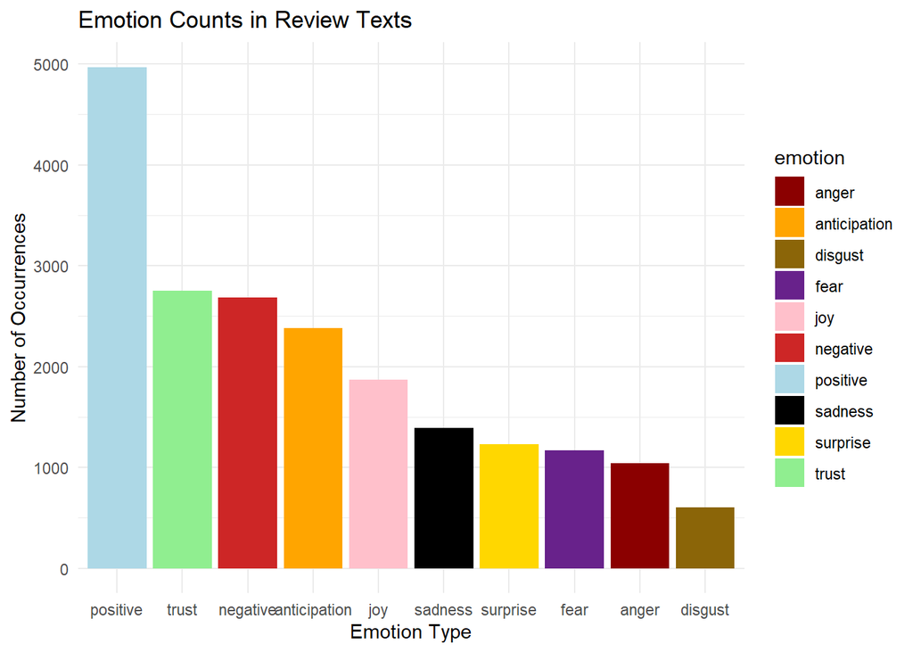

```r
# correct? Yesir!
# Create the cleaned text.reviews tibble
text.reviews <- tibble(text = high_importance_reviews_clean$reviewText)

# Continue with sentiment analysis
ratings <- high_importance_reviews_clean$overall

emotions <- get_nrc_sentiment(text.reviews$text)
emotion_bar <- colSums(emotions)
emotion_sum <- data.frame(count = emotion_bar, emotion = names(emotion_bar))

# barplot for counting each different emotion and positive/negative reviews
# Let's play around and customize our emotions
emotion_colors <- c(
  "anger" = "darkred",
  "anticipation" = "orange",
  "disgust" = "darkgoldenrod4",
  "fear" = "darkorchid4",
  "joy" = "pink",
  "sadness" = "black",
  "surprise" = "gold",
  "trust" = "lightgreen",
  'positive'= "lightblue",
  'negative'= "firebrick3"

)

# plot
ggplot(emotion_sum, aes(x = reorder(emotion, -count), y = count, fill = emotion)) +
  geom_bar(stat = 'identity') +
  scale_fill_manual(values = emotion_colors) +
  labs(
    title = "Emotion Counts in Review Texts",
    x = "Emotion Type",
    y = "Number of Occurrences"
  ) +
  theme_minimal()
```

After cleaning the review data, I performed sentiment analysis to uncover the emotional tone of the reviews and identify common issues and factors contributing to customer satisfaction using the NRC Emotion Lexicon which is a list of 5,636 English words associated with eight basic emotions (anger, fear, anticipation, trust, surprise, sadness, joy, and disgust) and two sentiments (negative and positive). To visualize the distribution of emotions in the review texts, I created a bar plot showing the count of each emotion type.

Now I use the tidytext package to ansIr: “What are the common issues reported in support tickets?” “What factors contribute to higher customer satisfaction? What about low satisfaction?”

I first create a one word per row dataset then I join in with the sentiments in the bing lexicon and count

### **Plotting commonly found sentiments**

```r
bing_word_counts <- text.reviews %>%
  unnest_tokens(output = word, input = text) %>%
  inner_join(get_sentiments("bing")) %>%
  count(word, sentiment, sort = TRUE)
```

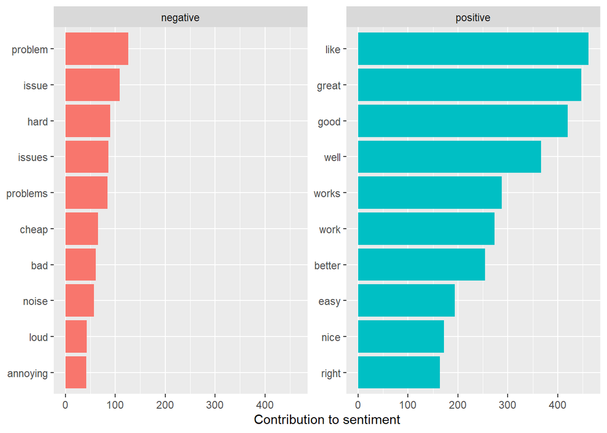

```r
# I select top 10 words by sentiment
bing_top_10_words_by_sentiment <- bing_word_counts %>%
  group_by(sentiment) %>%
  slice_max(order_by = n, n = 10) %>%
  ungroup() %>%
  dplyr::mutate(word = reorder(word, n))

# plot
# barplot to show the contribution of words to each sentiment
bing_top_10_words_by_sentiment %>%
  ggplot(aes(word, n, fill = sentiment)) +
  geom_col(show.legend = FALSE) +
  facet_wrap(~sentiment, scales = "free_y") +
  labs(y = "Contribution to sentiment", x = NULL) +
  coord_flip()
```

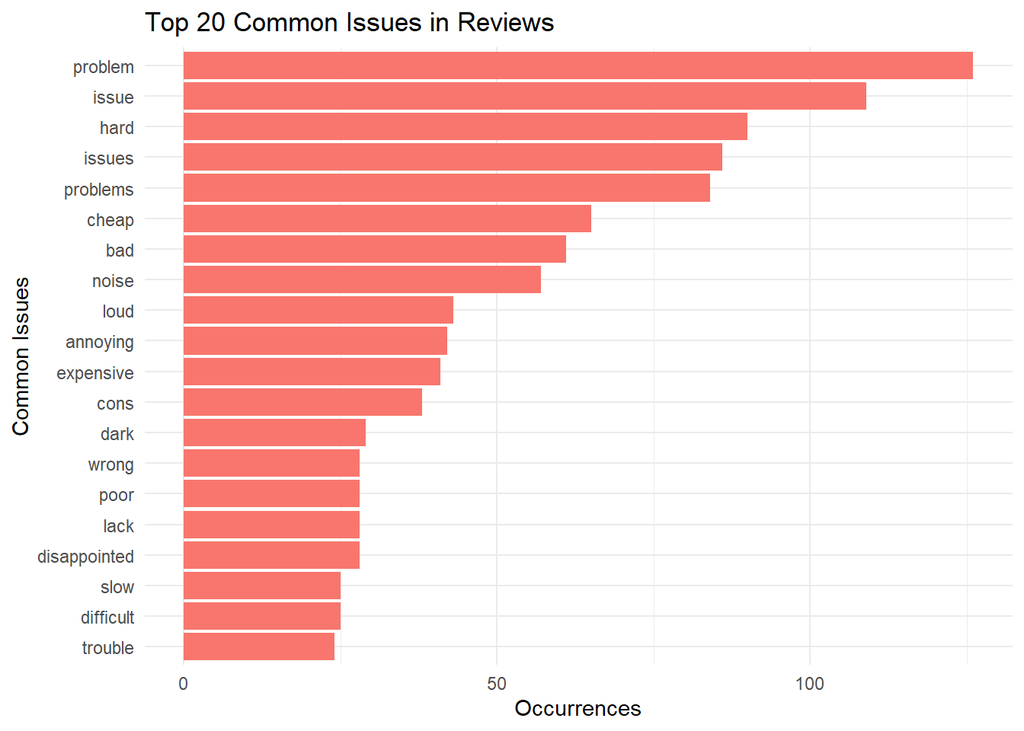

```r
# Filter negative sentiment words
negative_issues <- bing_word_counts %>%
  filter(sentiment == "negative" | sentiment %in% c("anger", "fear", "disgust", "sadness"))

# Selecting top 20 negative words indicating common issues
top_negative_issues <- negative_issues %>%
  slice_max(order_by = n, n = 20) %>%
  dplyr::mutate(word = reorder(word, n))

# plot
# Bar plot of common negative issues
ggplot(top_negative_issues, aes(word, n, fill = sentiment)) +
  geom_col(show.legend = FALSE) +
  labs(y = "Occurrences", x = "Common Issues", title = "Top 20 Common Issues in Reviews") +
  coord_flip() +
  theme_minimal()
```

among top 20 common issues are words such as “problem”, or “issue” which does not say much but I also observe words such as: “cheap” with around 60 occurrences - which most likely refers to quality” or “wrong” which may refer to wrong product being delivered

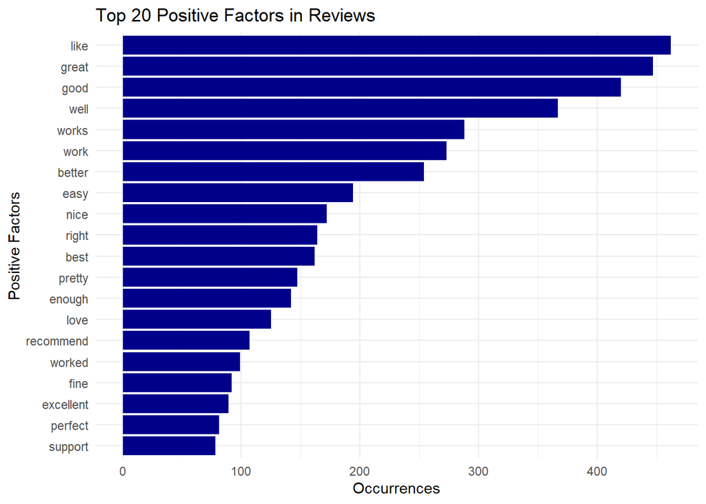

```r
# Filter positive sentiment words
positive_factors <- bing_word_counts %>%
  filter(sentiment == "positive" | sentiment %in% c("joy", "trust"))

# Select top 20 positive words indicating customer satisfaction factors
top_positive_factors <- positive_factors %>%
  slice_max(order_by = n, n = 20) %>% #returns the largest observation in each group, specified by n (the obs to extract)
  dplyr::mutate(word = reorder(word, n))

# plot
# Bar plot of factors contributing to customer satisfaction
ggplot(top_positive_factors, aes(word, n, fill = sentiment)) +
  geom_col(fill = "darkblue", show.legend = FALSE) +
  labs(y = "Occurrences", x = "Positive Factors", title = "Top 20 Positive Factors in Reviews") +
  coord_flip() +
  theme_minimal()
```

### **Bi-grams & Tri-grams** I am going to use a bi-gram and tri-gram approach to go beyond “one-word” occurrences and try finding possible meaningful relationships between reviews and common words used this way I may be able to find What factors contribute to SatiscationScores or patterns that align with the the customers being dissatisfied

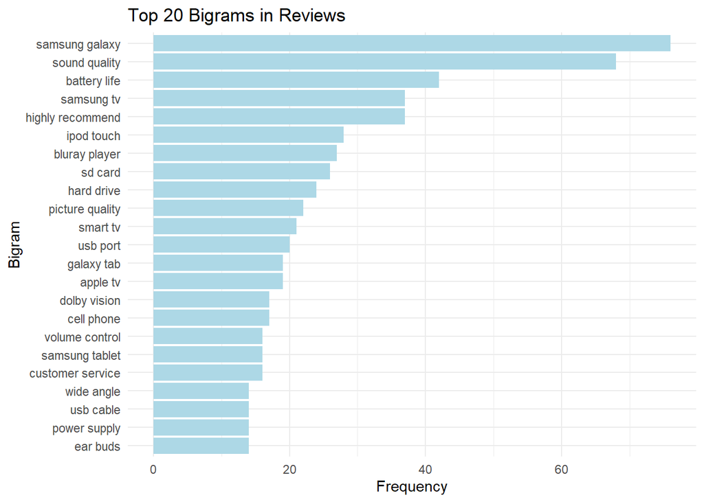

```r
# Tokenize the text data into bi-grams and tri-grams
# I am trying to find commonly used phrases of 2 and 3 words
bigrams <- high_importance_reviews_clean %>%
  unnest_tokens(bigram, reviewText, token = "ngrams", n = 2)

trigrams <- high_importance_reviews_clean %>%
  unnest_tokens(trigram, summary, token = "ngrams", n = 3)

# Separate the created n-grams into individual words (klinda like the ingridients of a sandwich)
bigrams_separated <- bigrams %>%
  separate(bigram, into = c("word1", "word2"), sep = " ")

trigrams_separated <- trigrams %>%
  separate(trigram, into = c("word1", "word2", "word3"), sep = " ")

# Remove stop words and rows with any NA values (I don't care about "um" or "uh")
data("stop_words")
# or "the", "and"
bigrams_filtered <- bigrams_separated %>%
  filter(!word1 %in% stop_words$word & !word2 %in% stop_words$word) %>%
  filter(!is.na(word1) & !is.na(word2))

trigrams_filtered <- trigrams_separated %>%
  filter(!word1 %in% stop_words$word & !word2 %in% stop_words$word & !word3 %in% stop_words$word) %>%
  filter(!is.na(word1) & !is.na(word2) & !is.na(word3))

# Frequency of words? Which combination of phrases are most common?
bigram_counts <- bigrams_filtered %>%
  count(word1, word2, sort = TRUE)

trigram_counts <- trigrams_filtered %>%
  count(word1, word2, word3, sort = TRUE)

# Combine the words back into n-grams (make the sandwich with the above seperate ingredients)
bigram_counts <- bigram_counts %>%
  unite(bigram, word1, word2, sep = " ")

trigram_counts <- trigram_counts %>%
  unite(trigram, word1, word2, word3, sep = " ")

# Let's check top 20 words
top_20_bigrams <- bigram_counts %>%
  slice_max(n, n = 20)

top_20_trigrams <- trigram_counts %>%
  slice_max(n, n = 20)

# plot
# Plotting the top 20 bigrams
ggplot(top_20_bigrams, aes(x = reorder(bigram, n), y = n)) +
  geom_col(fill = "lightblue") +
  coord_flip() + # Flip the axes for better readability
  labs(title = "Top 20 Bigrams in Reviews",
       x = "Bigram",
       y = "Frequency") +
  theme_minimal()
```

```r
print(top_20_bigrams)
```

```
##              bigram  n
## 1    samsung galaxy 76
## 2     sound quality 68
## 3      battery life 42
## 4  highly recommend 37
## 5        samsung tv 37
## 6        ipod touch 28
## 7     bluray player 27
## 8           sd card 26
## 9        hard drive 24
## 10  picture quality 22
## 11         smart tv 21
## 12         usb port 20
## 13         apple tv 19
## 14       galaxy tab 19
## 15       cell phone 17
## 16     dolby vision 17
## 17 customer service 16
## 18   samsung tablet 16
## 19   volume control 16
## 20         ear buds 14
## 21     power supply 14
## 22        usb cable 14
## 23       wide angle 14
```

```r
# lot of occurences for Samsung Galaxy and sound quality
print(top_20_trigrams)
```

```
##                              trigram n
## 1                samsung galaxy note 2
## 2                 samsung galaxy tab 2
## 3             abovetv soundbar mount 1
## 4             absolute utter rubbish 1
## 5           accurate dualalarm clock 1
## 6             active epson valueview 1
## 7            adapter reference chart 1
## 8        adding bluetooth capability 1
## 9           adventure camera leaking 1
## 10             affordable super easy 1
## 11              aluminum macbook ghz 1
## 12           amazing computing power 1
## 13                amazon price match 1
## 14             amazon prime customer 1
```

[output cut: 302 more lines]

Categorization (High vs Low ratings) - congruent with our modelling binary var

```r
high_importance_reviews_clean <- high_importance_reviews_clean %>%
  dplyr::mutate(review_category = case_when(
    overall %in% c(1, 2, 3) ~ "Low",
    overall %in% c(4, 5) ~ "High"
  ))

data("stop_words")
```

###**Tokens**

```r
# First, breaking down the review text into pairs of consecutive words
# Then split the bigrams into individual words and removes any that are NA or common stop words
bigrams_by_category <- high_importance_reviews_clean %>%
  unnest_tokens(bigram, summary, token = "ngrams", n = 2) %>%
  separate(bigram, into = c("word1", "word2"), sep = " ") %>%
  filter(!is.na(word1) & !is.na(word2)) %>%  # Remove rows with NA values
  filter(!word1 %in% stop_words$word & !word2 %in% stop_words$word) %>%
  count(review_category, word1, word2, sort = TRUE) %>%
  unite(bigram, word1, word2, sep = " ") # Counting how often specific pairs of words like "great product" appear and noting it down.

# Same thing here: tokenize, sepearate and filter + count and unite
trigrams_by_category <- high_importance_reviews_clean %>%
  unnest_tokens(trigram, summary, token = "ngrams", n = 3) %>%
  separate(trigram, into = c("word1", "word2", "word3"), sep = " ") %>%
  filter(!is.na(word1) & !is.na(word2) & !is.na(word3)) %>%  # Remove rows with NA values
  filter(!word1 %in% stop_words$word & !word2 %in% stop_words$word & !word3 %in% stop_words$word) %>%
  count(review_category, word1, word2, word3, sort = TRUE) %>%
  unite(trigram, word1, word2, word3, sep = " ")


# top 20 bigrams for each review category
top_bigrams_low <- bigrams_by_category %>%
  filter(review_category == "Low") %>%
  slice_max(n, n = 20, with_ties = TRUE) # Selects the top 20 rows with the highest values in column n, where I limit n to the top 20 bigrams
# and if there are ties (bigrams counts that are equal), I include them
# So, if the 20th and subsequent positions have the same count, they will all be included, potentially exceeding the specified limit of 20.

top_bigrams_high <- bigrams_by_category %>%
  filter(review_category == "High") %>%
  slice_max(n, n = 20, with_ties = TRUE)

# Top 20 Trigrams for Low and High ratings
top_trigrams_low <- trigrams_by_category %>%
  filter(review_category == "Low") %>%
  slice_max(n, n = 20, with_ties = TRUE)

top_trigrams_high <- trigrams_by_category %>%
  filter(review_category == "High") %>%
  slice_max(n, n = 20, with_ties = TRUE)

# Listing the results
print("Top 20 Bigrams in Low Ratings:")
```

```
## [1] "Top 20 Bigrams in Low Ratings:"
```

```r
print(top_bigrams_low)
```

```
##     review_category                  bigram n
## 1               Low             wouldnt buy 3
## 2               Low          samsung galaxy 2
## 3               Low      samsung headphones 2
## 4               Low           sound quality 2
## 5               Low          absolute utter 1
## 6               Low          actual product 1
## 7               Low  adequately refurbished 1
## 8               Low         android fragile 1
## 9               Low           android phone 1
## 10              Low      annoying listening 1
## 11              Low     annoying problemsso 1
## 12              Low              anti glare 1
## 13              Low       app compatibility 1
## 14              Low               app store 1
```

[output cut: 205 more lines]

```r
print("Top 20 Bigrams in High Ratings:")
```

```
## [1] "Top 20 Bigrams in High Ratings:"
```

```r
print(top_bigrams_high)
```

```
##    review_category            bigram  n
## 1             High    samsung galaxy 10
## 2             High     sound quality  4
## 3             High      battery life  3
## 4             High        ipod touch  3
## 5             High        super easy  3
## 6             High   amazing product  2
## 7             High    apple products  2
## 8             High bluetooth speaker  2
## 9             High     bluray player  2
## 10            High           buy buy  2
## 11            High        cell phone  2
## 12            High   excellent price  2
## 13            High excellent product  2
## 14            High      excellent tv  2
## 15            High  external battery  2
## 16            High       galaxy note  2
## 17            High        galaxy tab  2
## 18            High         ipad mini  2
## 19            High         ive owned  2
## 20            High   lightning cable  2
## 21            High       memory card  2
## 22            High  multiple devices  2
## 23            High        nice color  2
## 24            High       price range  2
## 25            High    samsung tablet  2
## 26            High wonderful product  2
```

```r
print("Top 20 Trigrams in Low Ratings:")
```

```
## [1] "Top 20 Trigrams in Low Ratings:"
```

```r
print(top_trigrams_low)
```

```
##    review_category                       trigram n
## 1              Low        absolute utter rubbish 1
## 2              Low  annoying problemsso annoying 1
## 3              Low               anti glare film 1
## 4              Low            apple tvdont waste 1
## 5              Low avoidable design shortcomings 1
## 6              Low       bit isolated connecting 1
## 7              Low                  blu ray till 1
## 8              Low       bluetooth latency delay 1
## 9              Low        bose headphones iphone 1
## 10             Low          bright snooze button 1
## 11             Low              burning br video 1
## 12             Low           camera motion shots 1
## 13             Low            canon fs camcorder 1
## 14             Low           charger cradle dock 1
```

[output cut: 63 more lines]

```r
print("Top 20 Trigrams in High Ratings:")
```

```
## [1] "Top 20 Trigrams in High Ratings:"
```

```r
print(top_trigrams_high)
```

```
##     review_category                          trigram n
## 1              High              samsung galaxy note 2
## 2              High               samsung galaxy tab 2
## 3              High           abovetv soundbar mount 1
## 4              High         accurate dualalarm clock 1
## 5              High           active epson valueview 1
## 6              High          adapter reference chart 1
## 7              High      adding bluetooth capability 1
## 8              High         adventure camera leaking 1
## 9              High            affordable super easy 1
## 10             High             aluminum macbook ghz 1
## 11             High          amazing computing power 1
## 12             High               amazon price match 1
## 13             High            amazon prime customer 1
## 14             High     amazonbasics apple certified 1
```

[output cut: 225 more lines]

“I found consistency in key words such as ‘Samsung Galaxy’ in high ratings and ‘cheap’ in low ratings across bigrams and trigrams, which aligns with domain-specific expectations like quality concerns or brand recognition. The counts and relative frequencies are computed systematically, and including ties in the rankings ensured no significant patterns Ire overlooked.”

## **Topic Modeling with LDA**

```r
# Set seed for reproducibility
set.seed(1234)

# First: extract the necessary columns and clean the text by removing numbers and punctuation.
review_data <- high_importance_reviews_clean %>%
  select(reviewerID, overall, reviewText) %>%
  dplyr::mutate(text = gsub(x = reviewText, pattern = "[0-9]+|[[:punct:]]|\\(.*\\)", replacement = ""))

# Second: matrix format where rows are documents (reviews) and columns are features (words)
tokens <- tokens(review_data$text, remove_punct = TRUE)

dfm <- dfm(tokens) %>%
  dfm_remove(stopwords("english")) %>%
  dfm_trim(min_termfreq = 10)

# Convert DFM for use in topic modeling
dfmlda <- convert(dfm, to = "topicmodels")
```

The Document-Feature Matrix (DFM) transforms the text data into a structured format where each row represents a document (in our case, reviews) and each column represents a term. This matrix format is necessary for applying topic modeling algorithms, as it quantifies the presence of terms across documents, enabling the identification of patterns and topics.

What are the limitations of using LDA for topic modeling? results depend heavily on how text is cleaned, tokenized, and filtered. LDA assumes topics are represented by word distributions, which may oversimplify complex relationships in text. The coherence of topics often requires domain expertise to validate.

```r
# Fit LDA model with k = 5 topics using Gibbs sampling
topic_5_gibbs <- LDA(dfmlda, k = 5, method = "Gibbs", control = list(seed = 5648, alpha = 0.8))

# Get top 10 terms for each topic
get_terms(topic_5_gibbs, 10)
```

```
##       Topic 1    Topic 2     Topic 3   Topic 4 Topic 5
##  [1,] "iphone"   "sound"     "tv"      "can"   "camera"
##  [2,] "case"     "iphone"    "samsung" "one"   "video"
##  [3,] "great"    "good"      "picture" "dont"  "can"
##  [4,] "ipad"     "speaker"   "price"   "im"    "power"
##  [5,] "use"      "bluetooth" "player"  "just"  "card"
##  [6,] "like"     "quality"   "great"   "use"   "even"
##  [7,] "cable"    "volume"    "good"    "like"  "better"
##  [8,] "works"    "music"     "hdmi"    "get"   "light"
##  [9,] "tablet"   "phone"     "amazon"  "ive"   "gb"
## [10,] "keyboard" "use"       "mount"   "now"   "drive"
```

```r
# Calculate topic coherence
topic_coherence(topic_5_gibbs, dfmlda)
```

```
## [1] -111.40276  -80.01253 -109.63194  -70.13659 -101.45211
```

```r
# We can also try to remove the two scraping words "samsung" and "iphone" using dfm_remove(), and examine whether this improves our topics:
dfm1 <- dfm_remove(dfm, c("can", "will", "use", "get", "just", "one", "like", "dont", "s", "well")) #remove scraping words because we know that these will otherwise appear in all topics.
dfmlda1 <- convert(dfm1, to = "topicmodels")

# Repeat model specs
topic_5_gibbs1 = LDA(dfmlda1, k = 7, method = "Gibbs", control = list(
  seed = 5648,
  alpha = 0.8))
# we can experiment with different values of k to distinguish finer-grained issues (check if they overall after)

get_terms(topic_5_gibbs1, 10)
```

```
##       Topic 1   Topic 2  Topic 3    Topic 4   Topic 5    Topic 6      Topic 7
##  [1,] "camera"  "work"   "samsung"  "iphone"  "case"     "sound"      "tv"
##  [2,] "really"  "im"     "tablet"   "cable"   "fit"      "speaker"    "samsung"
##  [3,] "video"   "remote" "computer" "works"   "iphone"   "good"       "picture"
##  [4,] "quality" "set"    "note"     "charge"  "keyboard" "bluetooth"  "amazon"
##  [5,] "even"    "want"   "usb"      "great"   "great"    "volume"     "price"
##  [6,] "screen"  "app"    "drive"    "product" "little"   "quality"    "mount"
##  [7,] "battery" "now"    "laptop"   "ipad"    "ipad"     "phone"      "player"
##  [8,] "better"  "button" "monitor"  "ipod"    "enough"   "headphones" "hdmi"
##  [9,] "good"    "need"   "android"  "apple"   "size"     "music"      "good"
## [10,] "light"   "used"   "windows"  "phone"   "samsung"  "iphone"     "better"
```

```r
topic_5_vem1 = LDA(dfmlda1, k = 7, method = "VEM",control = list(
  seed = 5648,
  alpha = 0.8))

get_terms(topic_5_vem1, 10)
```

```
##       Topic 1      Topic 2    Topic 3     Topic 4    Topic 5   Topic 6
##  [1,] "sound"      "usb"      "speaker"   "case"     "camera"  "tv"
##  [2,] "iphone"     "charge"   "sound"     "iphone"   "video"   "samsung"
##  [3,] "headphones" "cable"    "speakers"  "ipad"     "card"    "picture"
##  [4,] "good"       "samsung"  "volume"    "great"    "gb"      "great"
##  [5,] "great"      "cables"   "cable"     "tablet"   "even"    "quality"
##  [6,] "quality"    "power"    "audio"     "works"    "samsung" "screen"
##  [7,] "ear"        "charging" "iphone"    "keyboard" "monitor" "price"
##  [8,] "phone"      "port"     "unit"      "samsung"  "screen"  "player"
##  [9,] "price"      "battery"  "bluetooth" "also"     "better"  "d"
## [10,] "bluetooth"  "hdr"      "music"     "bag"      "windows" "mount"
##       Topic 7
##  [1,] "app"
##  [2,] "iphone"
##  [3,] "device"
##  [4,] "ive"
##  [5,] "im"
##  [6,] "using"
##  [7,] "work"
##  [8,] "now"
##  [9,] "apps"
## [10,] "phone"
```

The number of topics was selected iteratively, balancing interpretability and coherence scores. A smaller k could oversimplify the results, while a larger k might introduce noisy or redundant topics. Testing with k = 5 and k = 7, we found that k = 7 produced more specific and actionable topics.

## **Conclusion**

This analysis has provided a comprehensive view of customer sentiment and feedback through the lens of Natural Language Processing. Sentiment analysis revealed the distribution of emotions within customer reviews, highlighting the prevalence of both positive sentiments like ‘trust’ and ‘joy,’ as well as negative emotions such as ‘anger’ and ‘sadness.’ This nuanced understanding allows for a more targeted approach to addressing customer concerns and reinforcing positive experiences.

While LDA proved effective in identifying key topic-word relationships, it’s important to acknowledge that clustering methodologies could offer a complementary perspective. Clustering, potentially enhanced by techniques like embedding, could group documents based on their topic distributions, revealing higher-level patterns in customer feedback. Although our focus remained on topic-word relationships, future work could explore this avenue to further enrich the analysis.

## **Learning Outcomes and Development Takeaways**

In developing this project, I have gained a deeper appreciation for the capabilities and intricacies of Natural Language Processing (NLP) techniques. Here’s what I’ve learned and how this experience has inspired me on short:

- Sentiment Analysis: Identifying emotions like “joy” or “anger” revealed the nuanced sentiment in customer reviews, aligning with key feedback themes.
- Tokenization: Bi-grams and tri-grams exposed common patterns like “Samsung Galaxy” and “cheap quality,” reflecting brand recognition and quality concerns.
- Topic Modeling: Experimenting with LDA taught me the importance of optimizing parameters and refining input data for clearer, actionable themes.
- Cross-Validation: Comparing outputs from topic modeling with sentiment analysis validated the relevance of identified topics.
- Stakeholder Insights: Findings led to actionable recommendations, such as refining product categorization for better analysis.
- Adaptability: Iterative improvements, like removing common words, highlighted how small adjustments improve outcomes.
- Future Directions: I recognized potential in exploring clustering techniques to complement topic modeling for deeper insights.

## **Next Steps**

- Improve topic coherence by refining stop-word removal.
- Explore predictive models integrating sentiment scores with customer satisfaction.
- A more detailed investigation should be conducted to quantify the relationship between identified topics and customer satisfaction.
- Investigate the use of clustering algorithms, potentially incorporating document embeddings

## **References**

- Imaginary company called E-tech Electronics using 34,686,770 Amazon reviews from 6,643,669 users on 2,441,053 products {Inspired from the Stanford Network Analysis Project (SNAP)} Datsets:
- User Demographics: Information about the users, including age, region, occupation, gender, education, and income group.
- Reviews: ChatGPT scrapped Amazon reviews and ratings given by users for different versions of the E-Tech Electronics products.
- Sales Data: Insights into the sales performance of various products across different regions and store types.
- Feedback and Support: Detailed feedback from users about product features and concerns, along with support tickets raised